# Homework for Week_11

Lipi

2023-04-25

# What are we supposed to do for today’s lab?

Working with intertidal data. Today you will need to use skills that you have learned in **working with words** to clean up some issues with the character data and use what you learned today to **reorder your factors into orders that make sense**. (Also the **column headers could be better**…). HINT: New package idea to fix this is using the *janitor package*.

**Your goal, as per usual, is to make a plot, any plot where one of the axes is a factor. Save everything in the appropriate folders.**

You have two possible files to play with in the data folder (you don’t HAVE to use both): intertidal.csv and intertidal_latitude.csv (as well as a data dictionary)

Importantly, if you decide to visualize anything by tide height it should go from **low to mid to high tide.**

# Load the libraries

```r
library(tidyverse)
library(here)
library(janitor)
```

```r
library(tidyr)
library(dplyr)
library(ggplot2)
library(ggthemes)
```

# Read in the data

```r
intertidal<-read_csv(here("Week_11","Data","intertidaldata.csv"))
glimpse(intertidal)
```

```
## Rows: 450
## Columns: 13
## $ Site                  <chr> "Scripps", "Scripps", "Scripps", "Scripps", "Scr…
## $ Transect              <dbl> 1, 1, 1, 2, 2, 2, 3, 3, 3, 4, 4, 4, 5, 5, 5, 6, …
## $ Quadrat               <chr> "Low  .", "Mid", "High", "Low", "Mid", "High", "…
## $ `Bare Rock`           <dbl> 25, 50, 20, 10, 40, 40, 0, 30, 60, 0, 45, 70, 5,…
## $ Algae                 <dbl> 75, 0, 50, 85, 5, 5, 100, 5, 4, 100, 10, 0, 70, …
## $ Mussels               <dbl> 0, 5, 1, 0, 10, 0, 0, 10, 1, 0, 3, 0, 0, 5, 0, 0…
## $ `Small Barnacles`     <dbl> 2, 50, 50, 0, 40, 55, 0, 40, 20, 0, 25, 25, 20, …
## $ `Large Barnacles`     <dbl> 5, 5, 0, 0, 1, 0, 1, 0, 0, 0, 15, 5, 5, 0, 0, 5,…
## $ `Gooseneck Barnacles` <dbl> 0, 0, 0, 5, 5, 0, 0, 30, 5, 0, 0, 0, 0, 0, 0, 0,…
## $ Anemone               <dbl> 3, 0, 0, 0, 0, 0, 0, 0, 0, 0, 5, 0, 0, 10, 0, 0,…
## $ `Whelks (Counts)`     <dbl> 0, 0, 0, 0, 0, 0, 0, 0, 1, 0, 0, 0, 0, 1, 0, 0, …
## $ `Crabs (Counts)`      <dbl> 0, 0, 0, 0, 0, 0, 0, 0, 0, 0, 0, 0, 0, 0, 0, 0, …
## $ `Stars (Counts)`      <dbl> 0, 0, 0, 0, 0, 0, 0, 0, 0, 0, 0, 0, 0, 0, 0, 0, …
```

```r
View(intertidal)
```

# Now lets clean by using our knowledge from **working with words** lecture and **reordering factor** using knowledge from today’s lecture

```r
clean_intertidal <- intertidal %>%
  clean_names() %>% # renames the column titles in default case, snake_case (Janitor package)
  mutate(quadrat = str_replace_all(quadrat, pattern = "\\.|[0-9]", replacement = " ")) %>% # deletes unwanted numbers in quadrat column
  mutate(quadrat = str_trim(quadrat)) %>% # trims the white space from quadrat column
  mutate(quadrat = factor(quadrat, levels = c("Low","Mid","High"))) %>% # converts quadrat into factors and arranges them from low-> mid -> high, which makes sense!
  filter(site == "Dana Point") %>% # filters values for only one site, Dana Point
  drop_na() # filters out everything that is not a complete row
head(clean_intertidal)
```

```
## # A tibble: 6 × 13
##   site     trans…¹ quadrat bare_…² algae mussels small…³ large…⁴ goose…⁵ anemone
##   <chr>      <dbl> <fct>     <dbl> <dbl>   <dbl>   <dbl>   <dbl>   <dbl>   <dbl>
## 1 Dana Po…       1 Low           0   100       0       0       0       0       0
## 2 Dana Po…       1 Mid           5    50      10      50      30       0       2
## 3 Dana Po…       1 High         15    25       5      60       5       0       2
## 4 Dana Po…       2 Low           2    95       0       0       1       0       3
## 5 Dana Po…       2 Mid           5    80      25      15      10       2       3
## 6 Dana Po…       2 High          2     1       3      95       2       0       0
## # … with 3 more variables: whelks_counts <dbl>, crabs_counts <dbl>,
## #   stars_counts <dbl>, and abbreviated variable names ¹transect, ²bare_rock,
## #   ³small_barnacles, ⁴large_barnacles, ⁵gooseneck_barnacles
```

# Let’s make a simple plot

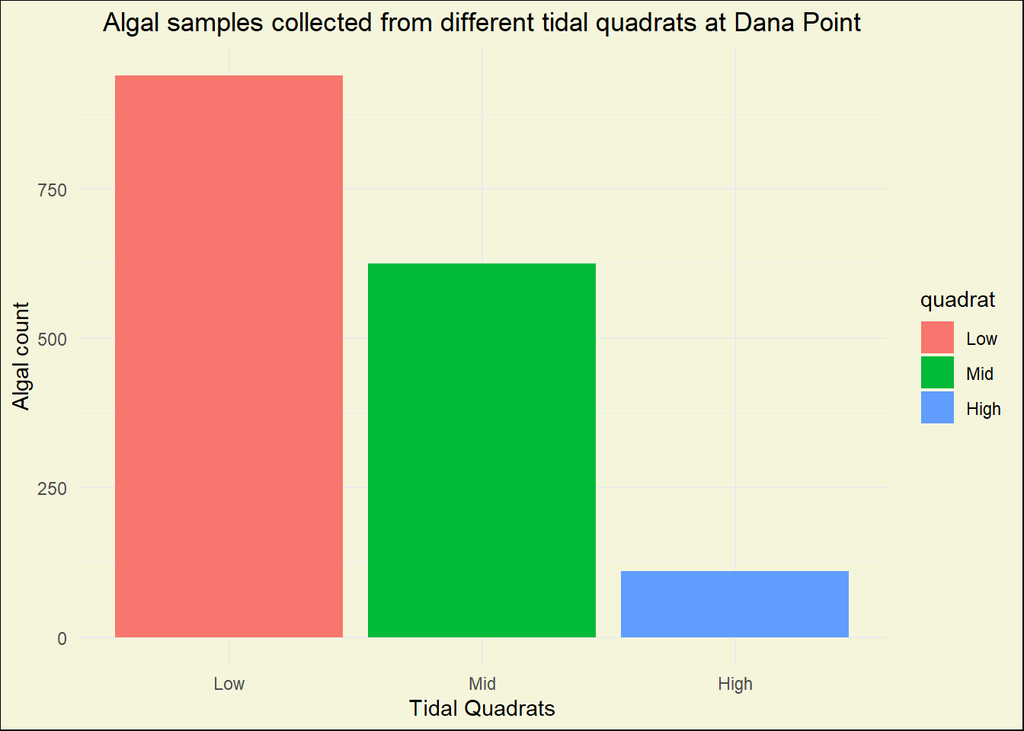

```r
clean_intertidal %>% # using the cleaned intertidal dataset
  ggplot(aes(x = quadrat, y = algae,
             fill = quadrat)) + # assigns xand y axes
  geom_col() + # chooses the geom to make a plot
  labs(x = "Tidal Quadrats", y = "Algal count",
       title = "Algal samples collected from different tidal quadrats at Dana Point") + # adds label to axes
  theme_minimal() + # chooses minimal theme to display
  theme(plot.title = element_text(hjust = 0.5), # center alignment for title
                plot.background = element_rect(fill = "beige")) # hanges background color
```

# Save your plot

```r
ggsave(here("Week_11","Output","Homework_for_Week_11.png"),
       width = 8, height = 4) # in inches)
```